# Statistical Inference Course Project part 2

Naveen Venkat Raj Jaladi

## Overview

This report aims to analyze the ToothGrowth data in the R datasets package. Per the course project instructions, the following items should occur:

1.Load the ToothGrowth data and perform some basic exploratory data analyses.

2.Provide a basic summary of the data.

3.Using confidence intervals and/or hypothesis tests to compare tooth growth by supp and dose(Only use the techniques from class, even if there’s other approaches worth considering).

4.Stating conclusions and the assumptions needed from conclusions.

## Exploratory Data Analysis

Dataset description:

The response is the length of odontoblasts (cells responsible for tooth growth) in 60 guinea pigs. Each animal received one of three dose levels of vitamin C (0.5, 1, and 2 mg/day) by one of two delivery methods, (orange juice or ascorbic acid (a form of vitamin C and coded as VC).

Codebook:

- len - numeric, Tooth length
- supp - factor, Supplement type (VC or OJ).
- dose - numeric, Dose in milligrams/day

Load data and required packages:

```r
library(ggplot2)
library(dplyr)
library(tidyr)
library(purrr)
library(broom)
options(tibble.width = Inf)
data("ToothGrowth")
```

Explore the dataset:

```r
glimpse(ToothGrowth)
```

```
## Observations: 60
## Variables: 3
## $ len  <dbl> 4.2, 11.5, 7.3, 5.8, 6.4, 10.0, 11.2, 11.2, 5.2, 7.0, 16.5, 16...
## $ supp <fct> VC, VC, VC, VC, VC, VC, VC, VC, VC, VC, VC, VC, VC, VC, VC, VC...
## $ dose <dbl> 0.5, 0.5, 0.5, 0.5, 0.5, 0.5, 0.5, 0.5, 0.5, 0.5, 1.0, 1.0, 1....
```

```r
summary(ToothGrowth)
```

```
##       len        supp         dose
##  Min.   : 4.20   OJ:30   Min.   :0.500
##  1st Qu.:13.07   VC:30   1st Qu.:0.500
##  Median :19.25           Median :1.000
##  Mean   :18.81           Mean   :1.167
##  3rd Qu.:25.27           3rd Qu.:2.000
##  Max.   :33.90           Max.   :2.000
```

```r
ToothGrowth$dose <- factor(ToothGrowth$dose)
```

Exploring variables via visualization:

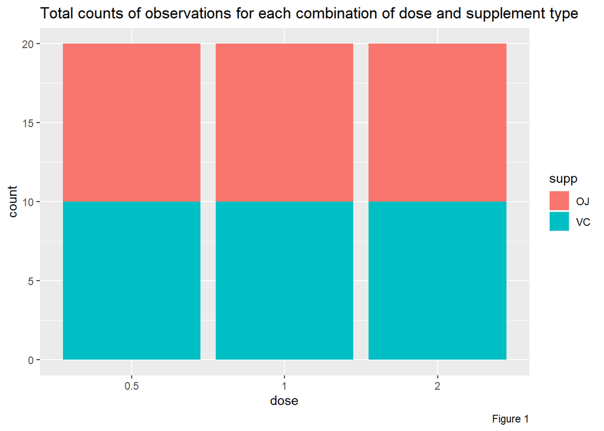

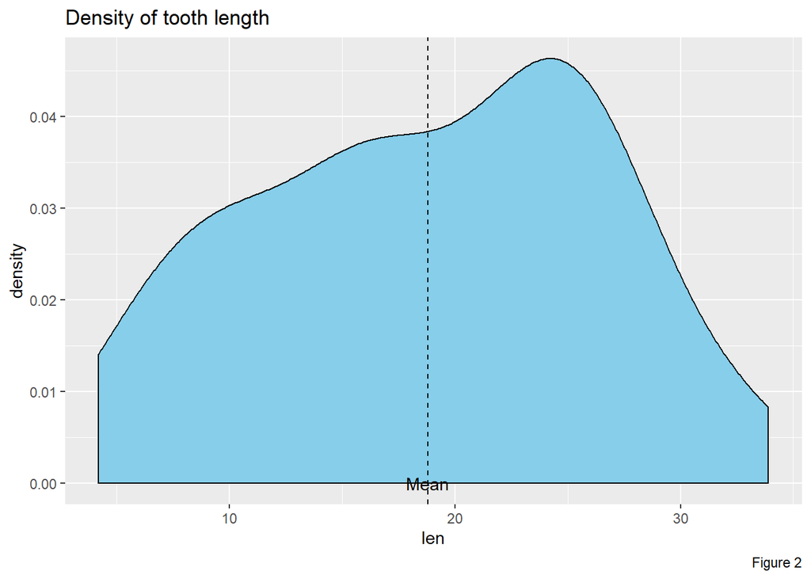

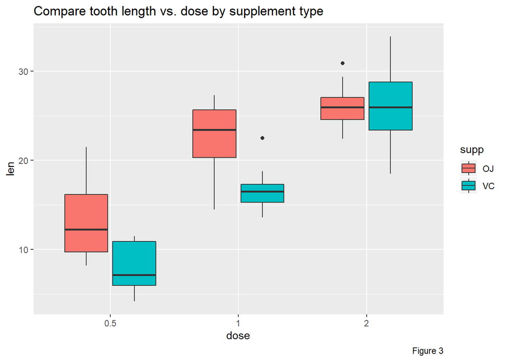

## Hypothesis test

Let’s calculate t-test for both groups.

1. Testing tooth growth by supplement delivery method:

Null Hypothesis : different supplement types have no effect on tooth length

```r
t.result1 <-
     tidy(t.test(len~supp, data = ToothGrowth)) %>%
     print()
```

```
## # A tibble: 1 x 10
##   estimate estimate1 estimate2 statistic p.value parameter conf.low conf.high
##      <dbl>     <dbl>     <dbl>     <dbl>   <dbl>     <dbl>    <dbl>     <dbl>
## 1     3.70      20.7      17.0      1.92  0.0606      55.3   -0.171      7.57
##   method                  alternative
##   <chr>                   <chr>
## 1 Welch Two Sample t-test two.sided
```

Here We can not reject the Null Hypothesis, cause the Confidence interval contains zero and also the p.value (0.0606345) is greater than 0.05.

2. Testing tooth growth by dose:

Null Hypothesis : dosage levels have no effect on tooth length

We will compare doses 0.5 with 1, 1 with 2 and 2 with 0.5

```r
t.result2 <-
ToothGrowth %>%
     mutate(dose.group = "0.5-1") %>%
     bind_rows(ToothGrowth) %>%
     mutate(dose.group = if_else(is.na(dose.group), "1-2", dose.group)) %>%
     bind_rows(ToothGrowth) %>%
     mutate(dose.group = if_else(is.na(dose.group), "2-0.5", dose.group)) %>%
     filter((dose.group == "0.5-1" & dose %in% c(.5, 1)) |
            (dose.group == "1-2" & dose %in% c(1, 2)) |
            (dose.group == "2-0.5" & dose %in% c(2, .5))) %>%
     select(-supp) %>%
     group_by(dose.group) %>%
     do(tidy(t.test(len~dose, data = .))) %>%
     print()
```

```
## # A tibble: 3 x 11
## # Groups:   dose.group [3]
##   dose.group estimate estimate1 estimate2 statistic  p.value parameter conf.low
##   <chr>         <dbl>     <dbl>     <dbl>     <dbl>    <dbl>     <dbl>    <dbl>
## 1 0.5-1         -9.13      10.6      19.7     -6.48 1.27e- 7      38.0   -12.0
## 2 1-2           -6.37      19.7      26.1     -4.90 1.91e- 5      37.1    -9.00
## 3 2-0.5        -15.5       10.6      26.1    -11.8  4.40e-14      36.9   -18.2
##   conf.high method                  alternative
##       <dbl> <chr>                   <chr>
## 1     -6.28 Welch Two Sample t-test two.sided
## 2     -3.73 Welch Two Sample t-test two.sided
## 3    -12.8  Welch Two Sample t-test two.sided
```

The confidence intervals for these doses groups allow us to reject the Null Hypothesis.

## Conclusion

Given the following assumptions:

- The sample is representative of the population.
- The distribution of the sample means follows the Central Limit Theorem.

In reviewing our t-test analysis from above, we can conclude that

## Appendices

Code to plot Figure 1:

```r
ggplot(ToothGrowth, aes(x = dose, fill = supp)) +
     geom_bar() +
     labs(caption = "Figure 1", title = "Total counts of observations for each combination of dose and supplement type")
```

Code to plot Figure 2:

```r
ggplot(ToothGrowth, aes(x = len)) +
     geom_density(fill = "skyblue") +
     geom_vline(xintercept = mean(ToothGrowth$len), lty = "dashed") +
     annotate(geom = "text", x = mean(ToothGrowth$len), y = 0, label = "Mean") +
     labs(caption = "Figure 2", title = "Density of tooth length")
```

Code to plot Figure 3:

```r
ggplot(ToothGrowth, aes(x = dose, y = len, fill = supp)) +
     geom_boxplot() +
     labs(caption = "Figure 3", title = "Compare tooth length vs. dose by supplement type")
```